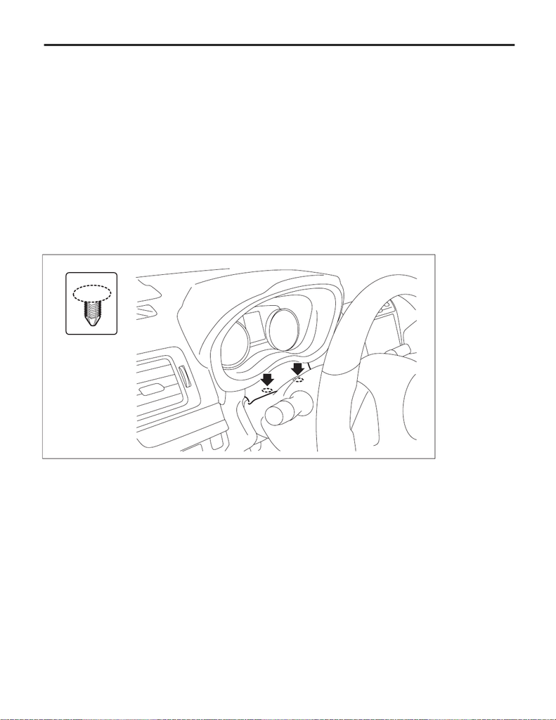

PS-25

Steering Column

POWER ASSISTED SYSTEM (POWER STEERING)

5. Steering Column

A: REMOVAL

CAUTION:

Before performing service on the airbag module, always refer to “CAUTION” of “General Descrip-

tion” in “AIRBAG SYSTEM” section. <Ref. to AB-9, CAUTION, General Description.>

1) Disconnect the ground cable from battery and wait for at least 60 seconds before starting work. <Ref. to

NT-5, BATTERY, NOTE, Note.>

NOTE:

For models other than STI model, disconnect the ground terminal from battery sensor.

2) Remove the cover assembly - instrument panel LWR driver. <Ref. to EI-61, REMOVAL, Instrument Panel

Lower Cover.>

3) Remove the knee airbag module. <Ref. to AB-35, REMOVAL, Knee Airbag Module.>

4) Remove the driver’s airbag module. <Ref. to AB-33, REMOVAL, Driver’s Airbag Module.>

5) Remove the steering wheel. <Ref. to PS-16, REMOVAL, Steering Wheel.>

6) Remove the cover assembly - column.

(1) Remove the clips, and remove the cover - column.

PS-01710

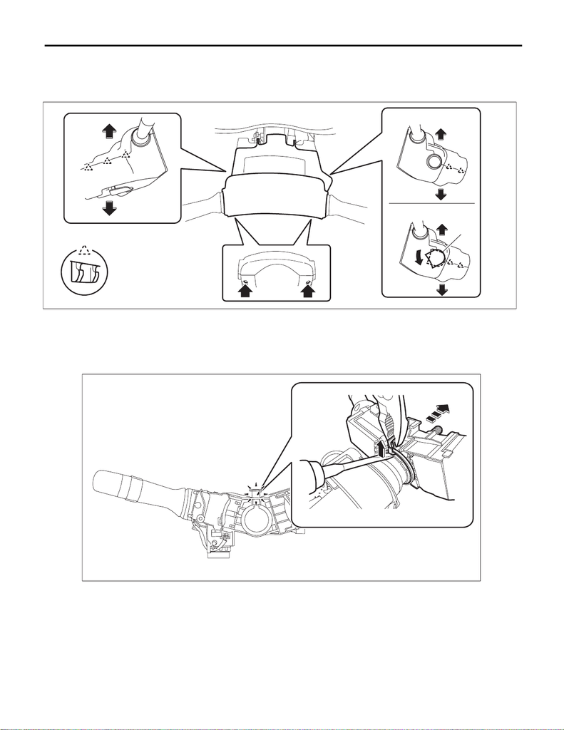

PS-26

Steering Column

POWER ASSISTED SYSTEM (POWER STEERING)

(2) Remove the screws.

(3) Remove the cap - key cylinder (a). (Model with keyless access)

(4) Release the claw, and remove the cover assembly - column UPR and the cover assembly - column

LWR.

7) Remove the switch assembly - combination.

(1) Disconnect the connector, and loosen the clamp to release the claws.

(2) Pull out the switch assembly - combination from the column assembly - steering.

A Model without keyless access B Model with keyless access

PS-01384

A

B

(a)

PS-01340

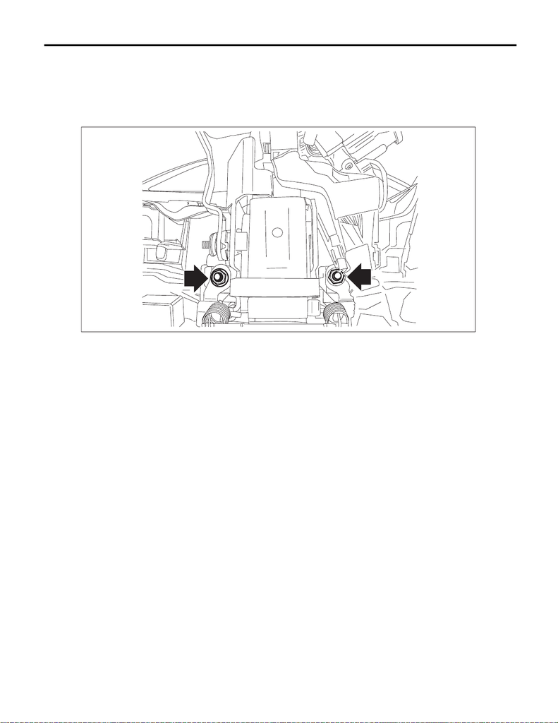

PS-27

Steering Column

POWER ASSISTED SYSTEM (POWER STEERING)

8) Remove all connectors from the column assembly - steering.

9) Remove the universal joint assembly - steering. <Ref. to PS-21, REMOVAL, Universal Joint.>

CAUTION:

To prevent damage to the universal joint assembly - steering and improper steering effort, make sure

to remove the universal joint assembly - steering.

11) Pull out the column assembly - steering from the hole on toe board.

CAUTION:

Do not loosen the tilt lever when the column assembly - steering is not secured to the vehicle.

12) Remove the ignition key lock. <Ref. to SL-64, REPLACEMENT, Ignition Key Lock.>

PS-01320

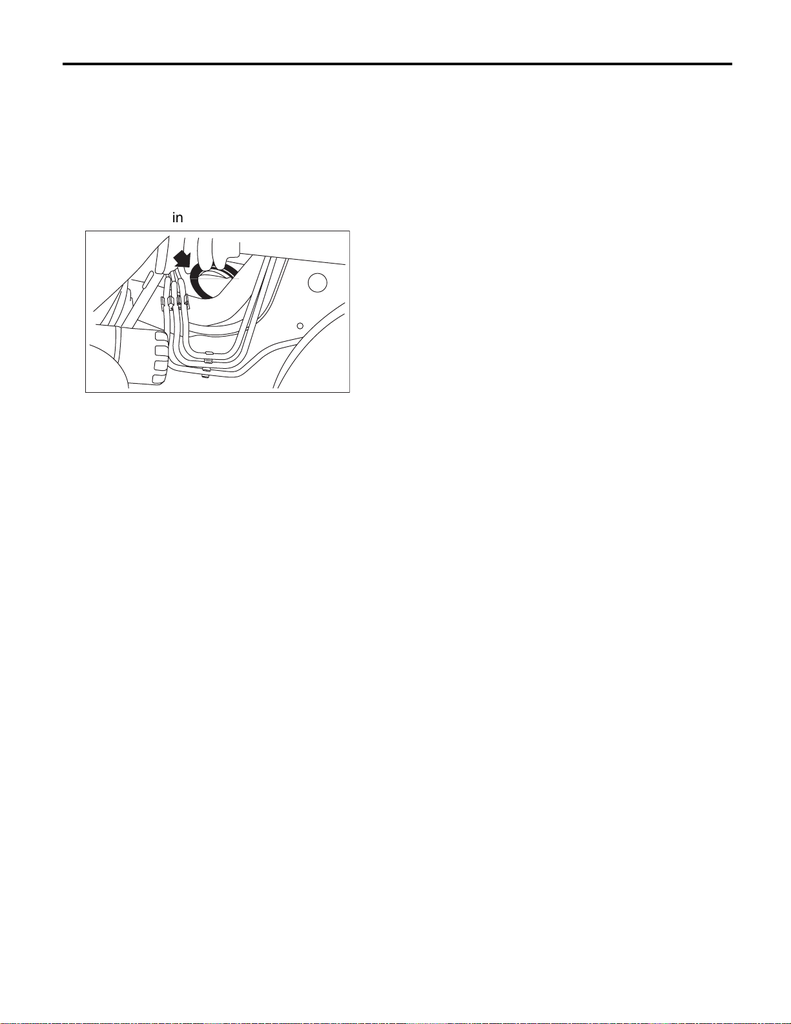

PS-28

Steering Column

POWER ASSISTED SYSTEM (POWER STEERING)

B: INSTALLATION

CAUTION:

• When removing, installing or replacing the VDCCM&H/U, VDCCM&H/U bracket, steering wheel or

steering angle sensor (steering roll connector), perform “VDC sensor midpoint setting mode” of the

VDC. <Ref. to VDC-16, VDC SENSOR MIDPOINT SETTING MODE, ADJUSTMENT, VDC Control Mod-

ule and Hydraulic Control Unit (VDCCM&H/U).>

• Before performing service on the airbag module, always refer to “CAUTION” of “General Descrip-

tion” in “AIRBAG SYSTEM” section. <Ref. to AB-9, CAUTION, General Description.>

1) Install the bushing to the toe board.

2) Insert the end of the column assembly - steering into the toe board bushing.

3) Tighten the column assembly - steering installation nut located under the beam COMPL - steering with the

tilt lever fixed.

Tightening torque:

20 N·m (2.0 kgf-m, 14.8 ft-lb)

4) Install the ignition key lock. <Ref. to SL-64, REPLACEMENT, Ignition Key Lock.>

5) Install the switch assembly - combination.

6) Connect all the connectors under the instrument panel.

7) Install the universal joint assembly - steering. <Ref. to PS-22, INSTALLATION, Universal Joint.>

CAUTION:

• Always install the universal joint assembly - steering after installing the steering column to avoid

damage to the universal joint assembly - steering.

• Be sure to follow the tightening order and tightening torque of the universal joint assembly - steer-

ing to avoid the steering effort from becoming heavy.

8) Install the knee airbag module. <Ref. to AB-35, INSTALLATION, Knee Airbag Module.>

9) Install the cover assembly - instrument panel LWR driver.

10) Install the cover assembly - column.

11) Align the center position of the steering roll connector. <Ref. to AB-64, ADJUSTMENT, Roll Connector.>

12) Install the steering wheel.

Tightening torque:

Steering wheel: 39 N·m (4.0 kgf-m, 28.8 ft-lb)

Clearance:

Between cover assembly - column and steering wheel: 4 — 6 mm (0.16 — 0.24 in)

13) Install the driver’s airbag module. <Ref. to AB-34, INSTALLATION, Driver’s Airbag Module.>

14) Connect the battery ground terminal. <Ref. to NT-5, BATTERY, NOTE, Note.>

NOTE:

For models other than STI model, connect the ground terminal to battery sensor.

PS-00041

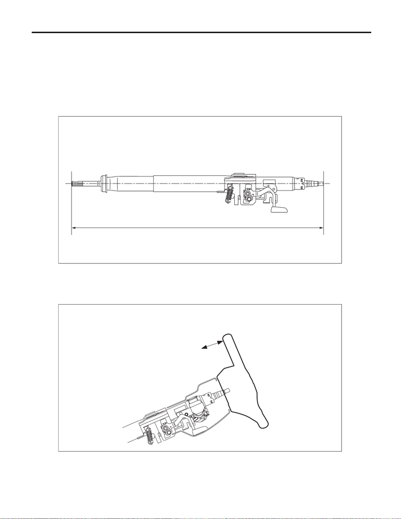

PS-29

Steering Column

POWER ASSISTED SYSTEM (POWER STEERING)

C: INSPECTION

1. UNIT INSPECTION

Check the following items, and if there is anything out of standard value, it is considered to be damaged. If

so, replace it with a new part.

• Measure the whole length of the column assembly - steering.

Standard: Overall length L

Tilt and telescopic column (measure while minimized)

819.7

+1.5

–1.5

mm (32.27

+0.059

–0.059

in)

• Check the steering wheel deflection in axial and vertical directions.

Specification:

Axial deflection A (deflection of steering wheel)

2. INSPECTION OF AIRBAG SYSTEM

Refer to “AIRBAG SYSTEM” section for airbag inspection procedure. <Ref. to AB-34, INSTALLATION, Driv-

er’s Airbag Module.>

L

PS-01328

PS-01751

A